# NC (036570) 기업 분석 보고서

Alpha Hunter Hidden Gem Week 22 — 게임 산업의 불사조, AION 2로 깨어난 턴어라운드의 신호탄

Author

Alpha Hunter × Chimera AI

Published

May 26, 2026

# 기업 개요

| 항목 | 내용 |
| --- | --- |
| **종목명** | NC (036570.KS) |
| **업종** | 게임 (Electronic Gaming & Multimedia) |
| **핵심 IP** | AION 2, 리니지 시리즈, TL(쓰론앤리버티), 블레이드&소울 |
| **시총** | 약 5.3조원 |
| **현재가** | 271,500원 |
| **Forward PER** | 11.7x |
| **EV/EBITDA** | 16.8x |
| **컨센서스** | Buy (23명 애널리스트) |
| **SEPA 점수** | 8/8 (Stage 2 완벽) |

## 0.1 투자 포인트 요약

> **“2024년 적자의 늪에서 AION 2로 화려하게 부활 — Q1 영업이익 +2,070% YoY, 매출 가이던스 2.5조원 상향”**
1. **Q1 2026 깜짝 실적** — 매출 5,574억원(+55% YoY), 영업이익 1,133억원(+2,070% YoY), 영업이익률 20.3%
2. **AION 2 글로벌 흥행** — 한국·대만 대성공, 북미·유럽 확장 예정(2026 하반기)
3. **연간 매출 가이던스 2.5조원** — 경영진 자신감, 내부 목표는 더 높음
4. **넷캐시 1.7조원** — 현금 2.07조 vs 부채 3,472억, 재무건전성 최상
5. **SEPA 8/8 완벽한 Stage 2** — 52주 고가 근접, 모든 이동평균선 정배열

**면책 고지**

이 프로젝트는 가상 투자 시뮬레이션 목적으로 작성되었습니다. 실제 투자 권유가 아닙니다.

# 1 SEPA 트렌드 템플릿

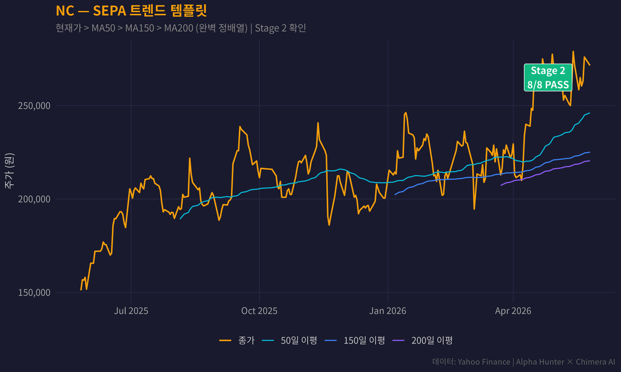

Figure 1: NC SEPA 트렌드 템플릿 — Stage 2 완벽 진입 (8/8)

**SEPA 체크리스트 (8/8 통과):**

- ✅ 현재가(271,500) > 150일 이평선 & 200일 이평선
- ✅ 150일 이평선 > 200일 이평선
- ✅ 200일 이평선 1개월 이상 상승추세
- ✅ 50일 이평선 > 150일 이평선 & 200일 이평선
- ✅ 현재가 > 50일 이평선
- ✅ 현재가(271,500) ≥ 52주 저가(151,140) × 1.30 = 196,482
- ✅ 현재가(271,500) ≥ 52주 고가(279,000) × 0.75 = 209,250
- ✅ 상대강도(RS) — 6개월 수익률 +21.5%

# 2 주가 추이 (52주)

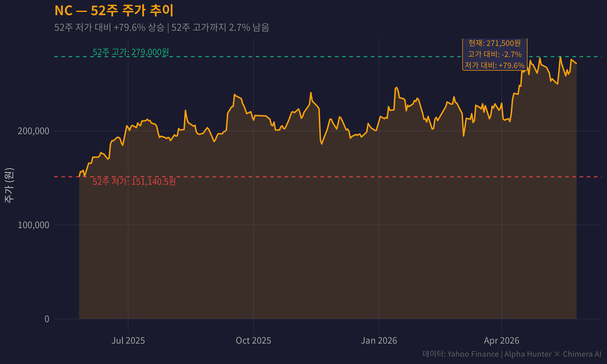

Figure 2: NC 52주 주가 추이 — 52주 고가 근접, 강력한 상승 모멘텀

# 3 실적 추이 (매출/영업이익)

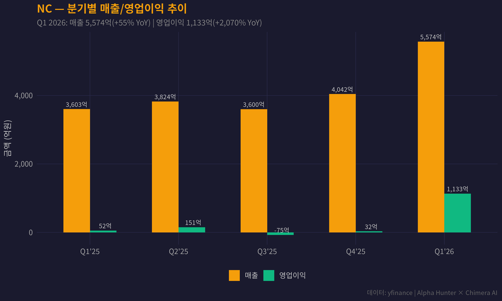

Figure 3: NC 분기별 실적 추이 — Q1 2026 턴어라운드 확정, 매출 +55% YoY 가속

**실적 분석:**

- **2024년 연간 영업적자 -1,077억원** → 2025년 흑자 전환(161억원) → **2026 Q1 단분기 1,133억원** 폭발
- 매출 가속: Q4’25 4,042억 → Q1’26 5,574억 (+38% QoQ)
- AION 2 + 리니지 클래식 + 모바일 캐주얼 사업의 3박자 성장
- **연간 매출 가이던스 2.5조원** (2025년 1.51조 대비 +66%)

# 4 밸류에이션 비교 (동종업종)

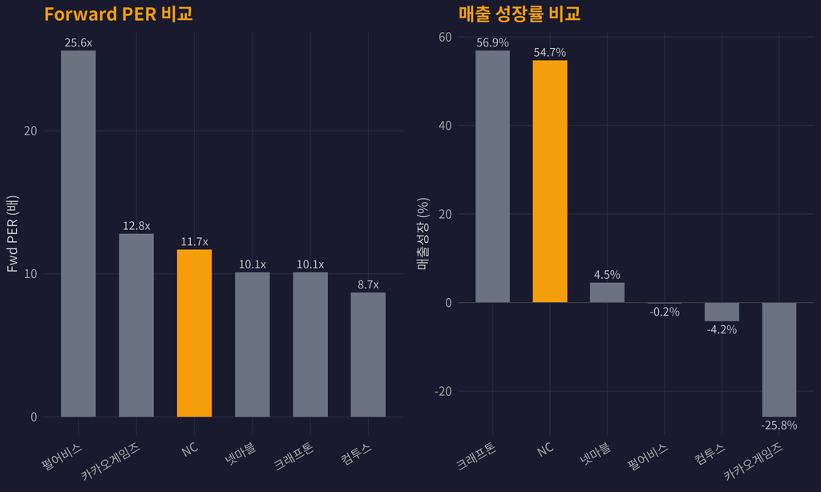

Figure 4: NC vs 동종업종 밸류에이션 비교 — Forward PER 11.7x로 상대적 저평가

**밸류에이션 핵심:**

- NC의 Fwd PER 11.7x는 매출 성장률 54.7%를 고려하면 **PEG 0.21** — 극단적 저평가
- 크래프톤(10.1x)과 비슷한 PER이지만 턴어라운드 모멘텀은 NC가 더 강력
- 애널리스트 목표가 평균 335,652원 (현재가 대비 +23.6% 상승 여력)

# 5 워런 버핏 해자 레이더 차트

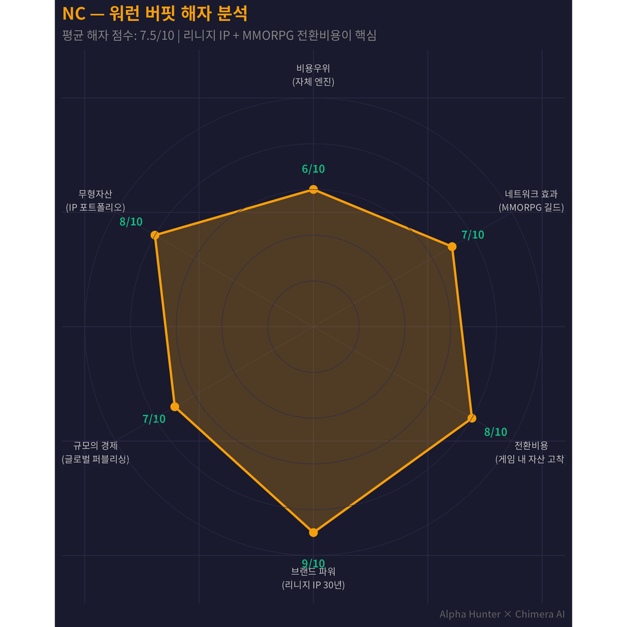

Figure 5: NC 해자(Moat) 분석 — IP 파워와 전환비용이 핵심 경쟁우위

**해자 분석:**

- **브랜드 파워 (9/10):** 리니지 IP는 30년 역사, 한국 게임 산업의 상징. AION, B&S 등 다중 IP 보유
- **전환비용 (8/10):** MMORPG 특성상 수년간 투자한 캐릭터·아이템에 대한 고착 효과
- **무형자산 (8/10):** 자체 게임 엔진(UE5 커스텀), AI 기술(VARCO LLM), 다수 IP 저작권

# 6 피터 린치 스토리 점수

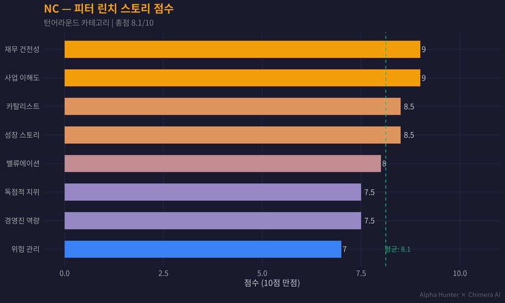

Figure 6: NC 피터 린치 스토리 점수 — 턴어라운드 플레이로 총점 8.1/10

**린치 분류: 턴어라운드(Turnaround)**

- 2024년 연간 영업적자 → 2026년 Q1 영업이익률 20% 회복 — 전형적 턴어라운드
- **사업 이해도 (9/10):** 누구나 아는 게임 회사, 리니지·AION 브랜드
- **재무 건전성 (9/10):** 넷캐시 1.7조원, 부채비율 9.8%
- **카탈리스트 (8.5/10):** AION 2 글로벌 확장, 신작 파이프라인, AI 사업

# 7 리스크 팩터 대시보드

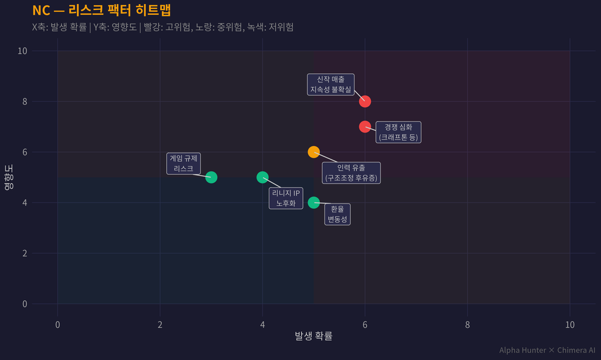

Figure 7: NC 리스크 팩터 대시보드 — 신작 의존도와 게임 산업 특성 리스크 존재

# 8 매수/목표/손절가 시나리오

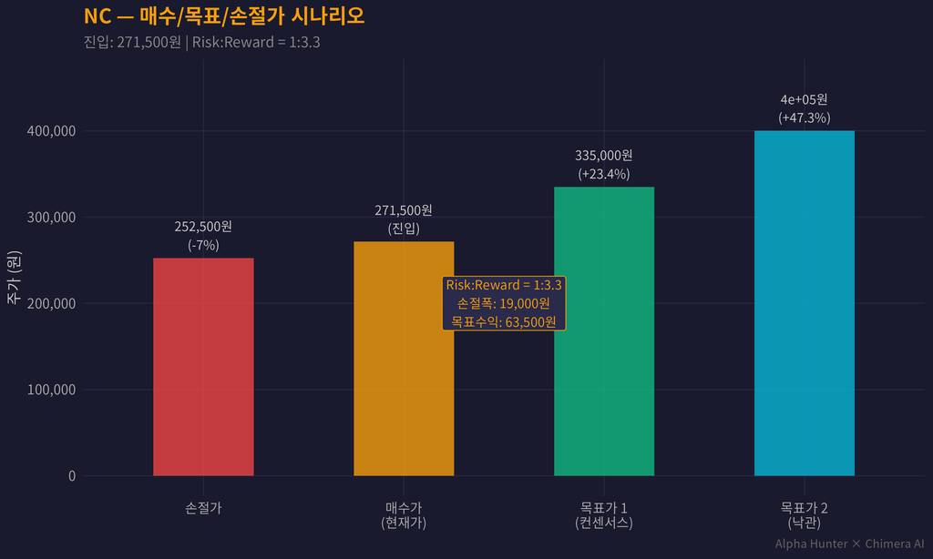

Figure 8: NC 매수/목표/손절가 시나리오 — R:R = 1:3.3 (목표 335,000원, 손절 252,500원)

**트레이딩 플랜:**

- **매수가:** 271,500원 (현재가 기준)
- **손절가:** 252,500원 (-7.0%) — SEPA 트렌드 이탈 시 즉시 손절
- **목표가 1:** 335,000원 (+23.4%) — 애널리스트 컨센서스 평균
- **목표가 2:** 400,000원 (+47.3%) — AION 2 글로벌 흥행 + 가이던스 상회 시
- **Risk:Reward = 1:3.3** — 최소 조건(1:3) 충족

# 9 투자 스토리 — 왜 지금 NC인가?

## 9.1 턴어라운드의 본질

NC는 2022년 이후 3년간 매출이 2.57조 → 1.51조로 -41% 감소하며 “몰락한 게임 공룡”이라는 낙인이 찍혔다. 하지만 2026년 Q1, AION 2와 리니지 클래식의 동시 흥행으로 **단분기 매출 5,574억, 영업이익 1,133억**을 달성하며 완벽한 턴어라운드를 시작했다.

## 9.2 핵심 카탈리스트

1. **AION 2 글로벌 확장 (2026 H2):** 한국·대만에서 대성공 후 북미·유럽 출시 예정. 3개월간 TL 대비 월등한 지표
2. **리니지 클래식:** 기존 리니지 IP의 재해석으로 안정적 매출 기반 확보
3. **AI 사업 (VARCO):** 자체 LLM 및 AI 기술로 게임 외 신사업 영역 개척
4. **연간 가이던스 2.5조원:** 2025년(1.51조) 대비 +66% 성장 목표, 경영진 자신감

## 9.3 재무 건전성

- **넷캐시 1.7조원** (현금 2.07조 - 부채 3,472억)
- 부채비율 9.8% — 게임업종 최저 수준
- FCF 2,748억원 — 주주환원 여력 충분

**Alpha Hunter 판단**

NC는 **펀더멘탈(매출 +55%, 영업이익률 20%)**과 **기술적 지표(SEPA 8/8)** 모두 충족하는 드문 턴어라운드 종목이다. 다만 AION 2의 매출 지속성이 핵심 변수이므로, Q2 실적 확인 시점까지 포지션을 단계적으로 구축하는 전략을 권장한다.

*이 프로젝트는 가상 투자 시뮬레이션 목적으로 작성되었습니다. 실제 투자 권유가 아닙니다.*